# pregunta_5v1

UNIVERSIDAD NACIONAL AGRARIA LA MOLINA

FACULTAD DE ECONOMÍA Y PLANIFICACIÓN

DEPARTAMENTO ACADÉMICO DE ESTADÍSTICA E INFORMÁTICA

[figure not shown]

TÉCNICAS MULTIVARIADAS

**Docente:** Miranda Villagomez, Clodomiro Fernando

EXAMEN PARCIAL

**Grupo:** 1

| Integrantes | Código |
| --- | --- |
| Meza Asto, Angel D. | 20220810 |
| Ormeño Sakihama, Daniel Kenyi | 20240723 |
| Ancco Guzman, Melany Alexandra | 20230379 |
| Pedraza Laboriano, Jonnathan | 20231505 |
| Fuentes Bueno, Fiorella | 20230395 |
| Garay Ramos, Jose Luis | 20230678 |
| Sobero Aguirre, Fiorella Romina | 20091130 |

LA MOLINA - LIMA - PERÚ

2026 - I

# 1 Análisis Factorial Dicotómico

## 1.1 Introducción

En el análisis de datos provenientes de encuestas de satisfacción o comportamiento del consumidor, es frecuente encontrarse con variables de naturaleza dicotómica (Sí/No, Presencia/Ausencia). El Análisis Factorial Dicotómico (AFD) surge como la herramienta estadística necesaria cuando el supuesto de continuidad de las variables observadas no se cumple.A diferencia del análisis factorial clásico que utiliza la correlación de Pearson, el AFD emplea la matriz de correlaciones tetracóricas. Este enfoque asume que detrás de cada respuesta binaria existe una propensión latente continua que sigue una distribución normal. En este estudio, aplicamos esta técnica para reducir la dimensionalidad de un conjunto de 12 indicadores sobre el comportamiento de usuarios en plataformas de E-Commerce en Perú.

Matemáticamente, para cada variable dicotómica observada $y_i$, el modelo tetracórico asume la existencia de una variable latente continua y subyacente $y_i^* \sim N(0,1)$, tal que la respuesta observada se define mediante un umbral $\tau_i$:

$$y_i =
\begin{cases}
1 & \text{si } y_i^* \geq \tau_i \\
0 & \text{si } y_i^* < \tau_i
\end{cases}$$

Es sobre estas variables latentes $y^*$ que se calcula la estructura de correlaciones, evitando la atenuación típica del coeficiente de Pearson.

Es fundamental precisar que para este estudio se ha seleccionado el Análisis Factorial Exploratorio (AFE) en lugar del Análisis de Componentes Principales (ACP). Esta decisión radica en que, mientras el ACP es una técnica descriptiva de reducción de datos que busca explicar la mayor parte de la variabilidad total con el menor número posible de componentes , el AFE permite construir un modelo para explicar la estructura causal y las interrelaciones latentes que subyacen a las variables observadas. De este modo, los factores se identifican a partir de la varianza común, tratando a los indicadores originales como variables dependientes de factores no observables que deben ser hallados para comprender el fenómeno estudiado.

## 1.2 Definición de Variables y Dimensiones Teóricas

| Dimensión Latente | Ítem | Descripción de la Variable (1 = Sí, 0 = No) |
| --- | --- | --- |
| **F1: Seguridad y Prevención** | P1 | Verifica que la página cuente con certificado HTTPS. |
| **F1: Seguridad y Prevención** | P2 | Evita guardar activamente los datos de su tarjeta en la web. |
| **F1: Seguridad y Prevención** | P3 | Lee exhaustivamente las políticas de devoluciones. |
| **F1: Seguridad y Prevención** | P4 | Utiliza pasarelas intermedias de pago (ej. PayPal, Apple Pay). |
| **F1: Seguridad y Prevención** | P5 | Evita realizar transacciones financieras en redes Wi-Fi públicas. |
| **F1: Seguridad y Prevención** | P11 | Utiliza autenticación de dos pasos (2FA) en sus cuentas de compra. |
| **F2: Hábitos de Consumo Digital** | P6 | Realiza compras por internet al menos una vez al mes. |
| **F2: Hábitos de Consumo Digital** | P7 | Prefiere utilizar las Apps oficiales de las tiendas sobre la web. |
| **F2: Hábitos de Consumo Digital** | P8 | Está suscrito a newsletters para recibir alertas de ofertas. |
| **F2: Hábitos de Consumo Digital** | P9 | Suele dejar reseñas o valoraciones de los productos adquiridos. |
| **F2: Hábitos de Consumo Digital** | P10 | Planifica sus compras para coincidir con días de descuento (Cyber). |
| **F2: Hábitos de Consumo Digital** | P12 | Comparte promociones u ofertas de tiendas en sus redes sociales. |

Bajo el enfoque de validación, el modelo de Análisis Factorial Exploratorio (AFE) asume que el vector de variables observadas $\mathbf{X}$ se puede expresar como una combinación lineal de factores comunes latentes $\mathbf{F}$ y un vector de errores o factores únicos $\mathbf{\epsilon}$:

$$\mathbf{X} = \boldsymbol{\mu} + \boldsymbol{\Lambda} \mathbf{F} + \boldsymbol{\epsilon}$$

## 1.3 Objetivos

1. Validar la estructura factorial de la encuesta mediante el uso de matrices tetracóricas.
2. Identificar las cargas factoriales bajo el método de extracción de Mínimos Cuadrados Ponderados (WLS).
3. Comparar la interpretabilidad del modelo mediante rotaciones ortogonales (Varimax).
4. Determinar el nivel de adecuación de la muestra para el análisis de reducción de datos.

## 1.4 Carga y Preparación de los Datos

Para garantizar la reproducibilidad y el ajuste óptimo del modelo bidimensional teórico, cargamos la base de datos de 12 indicadores. La muestra consta de $n = 500$ observaciones.

**Ver código R**

```r
## Carga y Preparación de los Datos
test <- read_excel("Datos_Dicotomicos.xlsx")

# Tamaño de muestra
n_obs <- nrow(test)

# Mostrar tabla interactiva
datatable(
  test,
  caption = "Visualización de la base de datos cargada",
  options = list(
    pageLength = 10,
    scrollX = TRUE,
    autoWidth = TRUE,
    language = list(
      search = "Buscar:",
      lengthMenu = "Mostrar _MENU_ registros",
      info = "Mostrando _START_ a _END_ de _TOTAL_ registros",
      paginate = list(
        "next" = "Siguiente",
        "previous" = "Anterior"
      )
    )
  )
)
```

|  | P1 | P2 | P3 | P4 | P5 | P6 | P7 | P8 | P9 | P10 | P11 | P12 |
| --- | --- | --- | --- | --- | --- | --- | --- | --- | --- | --- | --- | --- |
| 1 | 1 | 0 | 1 | 1 | 1 | 1 | 1 | 1 | 1 | 1 | 1 | 1 |
| 2 | 0 | 0 | 0 | 0 | 0 | 1 | 1 | 0 | 1 | 1 | 0 | 1 |
| 3 | 1 | 0 | 1 | 1 | 1 | 1 | 1 | 0 | 1 | 0 | 1 | 0 |
| 4 | 0 | 0 | 0 | 1 | 0 | 1 | 1 | 1 | 1 | 1 | 1 | 1 |
| 5 | 0 | 0 | 0 | 0 | 0 | 0 | 0 | 0 | 0 | 0 | 0 | 1 |
| 6 | 0 | 0 | 0 | 0 | 0 | 1 | 1 | 1 | 0 | 1 | 0 | 1 |
| 7 | 0 | 0 | 0 | 0 | 1 | 1 | 1 | 1 | 0 | 0 | 0 | 1 |
| 8 | 0 | 0 | 0 | 0 | 0 | 0 | 0 | 1 | 0 | 0 | 0 | 0 |
| 9 | 0 | 0 | 0 | 1 | 1 | 1 | 1 | 1 | 0 | 0 | 0 | 0 |
| 10 | 0 | 0 | 0 | 0 | 0 | 1 | 1 | 1 | 1 | 1 | 0 | 1 |

[output cut: 490 more lines]

## 1.5 Verificación de Supuestos

### 1.5.1 Análisis de Medias y “Factores de Dificultad”

Verificamos que las proporciones de respuesta no sean extremas para evitar sesgos de agrupación por frecuencia.

**Ver código R**

```r
prop_resp <- colMeans(test)
kable(t(round(prop_resp, 3)), caption = "Proporción de Respuestas Afirmativas") %>% kable_styling()
```

Proporción de Respuestas Afirmativas

| P1 | P2 | P3 | P4 | P5 | P6 | P7 | P8 | P9 | P10 | P11 | P12 |
| --- | --- | --- | --- | --- | --- | --- | --- | --- | --- | --- | --- |
| 0.496 | 0.53 | 0.478 | 0.514 | 0.53 | 0.468 | 0.498 | 0.46 | 0.532 | 0.47 | 0.512 | 0.474 |

**Interpretación Teórica:** Las proporciones de respuesta afirmativa oscilan entre **0.460 (P8)** y **0.532 (P9)**, manteniéndose todas muy próximas a 0.50. Esto garantiza la ausencia de “factores de dificultad”: ítems con proporciones extremas (< 0.20 o > 0.80) generarían agrupaciones artificiales basadas en frecuencia de respuesta y no en el contenido latente de las variables. Al cumplirse este supuesto, la agrupación factorial reflejará exclusivamente la estructura conceptual del instrumento.

### 1.5.2 Matriz de Correlaciones Tetracóricas

**Ver código R**

```r
# Cálculo de matriz tetracórica
r.tetra = tetrachoric(test)
```

**Ver código R**

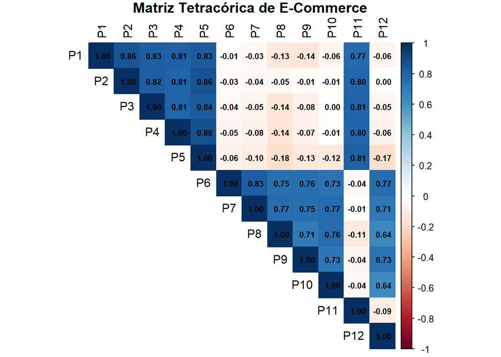

```r
R = r.tetra$rho

# Visualización gráfica
corrplot(R, method = "color", type = "upper", addCoef.col = "black",
         number.cex = 0.7, tl.col = "black", title = "Matriz Tetracórica de E-Commerce", mar=c(0,0,1,0))
```

**Ver código R**

```r
# Tabla numérica ← AQUÍ
kable(round(R, 2),
      caption = "Matriz de Correlaciones Tetracóricas") %>%
  kable_styling(bootstrap_options = c("striped", "condensed"),
                full_width = T, font_size = 11)
```

Matriz de Correlaciones Tetracóricas

|  | P1 | P2 | P3 | P4 | P5 | P6 | P7 | P8 | P9 | P10 | P11 | P12 |
| --- | --- | --- | --- | --- | --- | --- | --- | --- | --- | --- | --- | --- |
| P1 | 1.00 | 0.86 | 0.83 | 0.81 | 0.83 | -0.01 | -0.03 | -0.13 | -0.14 | -0.06 | 0.77 | -0.06 |
| P2 | 0.86 | 1.00 | 0.82 | 0.81 | 0.86 | -0.03 | -0.04 | -0.05 | -0.01 | -0.01 | 0.80 | 0.00 |
| P3 | 0.83 | 0.82 | 1.00 | 0.81 | 0.84 | -0.04 | -0.05 | -0.14 | -0.08 | 0.00 | 0.81 | -0.05 |
| P4 | 0.81 | 0.81 | 0.81 | 1.00 | 0.88 | -0.05 | -0.08 | -0.14 | -0.07 | -0.01 | 0.80 | -0.06 |
| P5 | 0.83 | 0.86 | 0.84 | 0.88 | 1.00 | -0.06 | -0.10 | -0.18 | -0.13 | -0.12 | 0.81 | -0.17 |
| P6 | -0.01 | -0.03 | -0.04 | -0.05 | -0.06 | 1.00 | 0.83 | 0.75 | 0.76 | 0.73 | -0.04 | 0.77 |
| P7 | -0.03 | -0.04 | -0.05 | -0.08 | -0.10 | 0.83 | 1.00 | 0.77 | 0.75 | 0.77 | -0.01 | 0.71 |
| P8 | -0.13 | -0.05 | -0.14 | -0.14 | -0.18 | 0.75 | 0.77 | 1.00 | 0.71 | 0.76 | -0.11 | 0.64 |
| P9 | -0.14 | -0.01 | -0.08 | -0.07 | -0.13 | 0.76 | 0.75 | 0.71 | 1.00 | 0.73 | -0.04 | 0.73 |
| P10 | -0.06 | -0.01 | 0.00 | -0.01 | -0.12 | 0.73 | 0.77 | 0.76 | 0.73 | 1.00 | -0.04 | 0.64 |
| P11 | 0.77 | 0.80 | 0.81 | 0.80 | 0.81 | -0.04 | -0.01 | -0.11 | -0.04 | -0.04 | 1.00 | -0.09 |
| P12 | -0.06 | 0.00 | -0.05 | -0.06 | -0.17 | 0.77 | 0.71 | 0.64 | 0.73 | 0.64 | -0.09 | 1.00 |

**Interpretación de la Matriz:** La matriz tetracórica revela una estructura de bloques muy definida. Los ítems de **Seguridad (P1-P5, P11)** presentan correlaciones internas en un rango de **0.77 a 0.88**, reflejando una fuerte cohesión conceptual. Los ítems de **Hábitos (P6-P10, P12)** muestran correlaciones internas entre **0.64 y 0.83**, igualmente elevadas. Crucialmente, las correlaciones **cruzadas entre ambos bloques** son prácticamente nulas (rango: **-0.18 a 0.00**), confirmando la independencia entre las dos dimensiones y anticipando con claridad la existencia de dos factores latentes ortogonales.

### 1.5.3 Pruebas de Factorabilidad

Evaluamos si la estructura de correlaciones permite la reducción de datos mediante la Prueba de Esfericidad de Bartlett y el Índice KMO.

**Ver código R**

```r
# Ejecución de pruebas
bartlett <- cortest.bartlett(R, n = n_obs)
kmo_res <- KMO(R)

# Comprobación de estructura según performance
check_factorstructure(R, n = n_obs)
```

```
# Is the data suitable for Factor Analysis?


  - Sphericity: Bartlett's test of sphericity suggests that there is sufficient significant correlation in the data for factor analysis (Chisq(66) = 6654.04, p < .001).
  - KMO: The Kaiser, Meyer, Olkin (KMO) overall measure of sampling adequacy suggests that data seems appropriate for factor analysis (KMO = 0.84). The individual KMO scores are: P1 (0.85), P2 (0.79), P3 (0.91), P4 (0.82), P5 (0.78), P6 (0.81), P7 (0.86), P8 (0.90), P9 (0.90), P10 (0.82), P11 (0.91)…
```

**Interpretación de Supuestos (Factorabilidad):**

1. **Prueba de Bartlett:** El estadístico χ²(66) = 6654.04 es altamente significativo ($p < 0.001$), confirmando que la matriz de correlaciones tetracóricas es significativamente distinta de una matriz identidad. En términos prácticos, esto indica que las preguntas están lo suficientemente interrelacionadas como para ser agrupadas en factores latentes. Si el p-valor fuera mayor a 0.05, el análisis factorial no estaría justificado.
2. **Índice KMO:** El valor global obtenido es de **0.84**, lo cual se califica como **“Meritorio”**. Esto nos asegura que la muestra es adecuada y que los resultados que obtendremos del análisis factorial serán estables y confiables.
3. **Análisis Individual (MSA):** Al revisar cada pregunta por separado, todas superan el mínimo aceptable de 0.50, situándose en un rango excelente de **0.76 a 0.91**. Esto es muy positivo, ya que indica que no es necesario eliminar ninguna variable del modelo; todas las preguntas (P1 a P12) están aportando información relevante al estudio.

En conclusión, la base de datos supera con éxito las pruebas de calidad y es totalmente apta para identificar las dimensiones de Seguridad y Hábitos de Consumo.

## 1.6 Determinación del Número de Factores

**Ver código R**

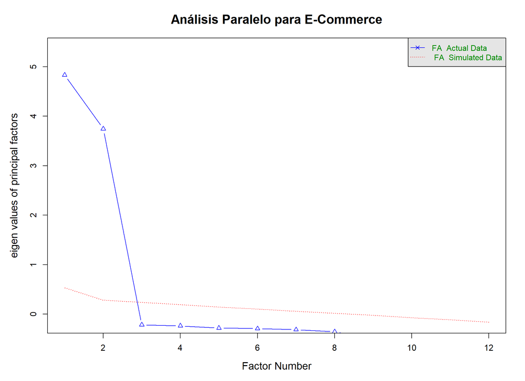

```
Parallel analysis suggests that the number of factors =  2  and the number of components =  NA
```

```r
par(
  mar = c(5,5,4,2),
  cex.main = 1.6,
  cex.lab  = 1.3,
  cex.axis = 1.1
)

fa.parallel(
  R,
  n.obs = n_obs,
  fa = "fa",
  fm = "wls",
  main = "Análisis Paralelo para E-Commerce"
)
```

**Interpretación del Análisis Paralelo:**

Esto significa que: 1. Solo existen **dos factores** cuya varianza es mayor a la que se obtendría por puro azar o ruido estadístico. 2. A partir del tercer factor, los puntos azules caen por debajo de la línea roja, indicando que añadir más dimensiones no aportaría valor real al modelo.

Este resultado confirma estadísticamente que la estructura de **2 factores** es la más adecuada y estable para explicar la encuesta, coincidiendo perfectamente con las dimensiones teóricas de Seguridad y Hábitos.

## 1.7 Modelamiento del Análisis Factorial

Se procede con la estimación utilizando el método de Mínimos Cuadrados Ponderados (WLS), recomendado para el tratamiento de matrices tetracóricas.

**Ver código R**

```r
# 1. Ajuste del modelo SIN rotar
factorial_sin_rotar = fa(test, nfactors = 2, n.obs = n_obs, rotate = "none", fm = "wls", cor = "tet")
```

**Ver código R**

```r
# 2. Ajuste del modelo CON rotación Varimax
factorial_final = fa(test, nfactors = 2, n.obs = n_obs, rotate = "varimax", fm = "wls", cor = "tet")
```

**Ver código R**

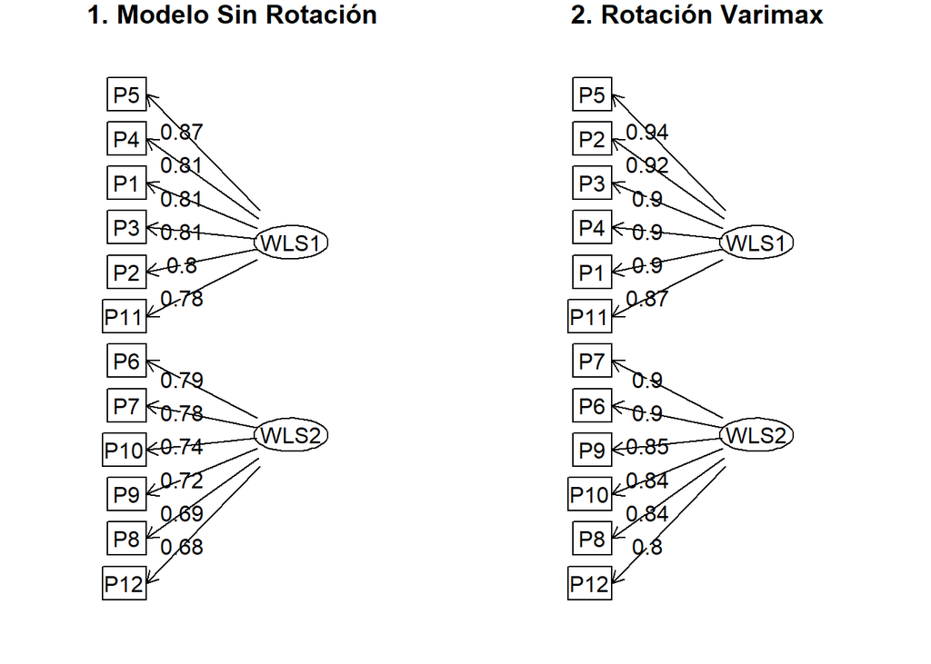

```r
# Configurar el panel para mostrar 2 gráficos lado a lado
par(mfrow = c(1, 2))
fa.diagram(factorial_sin_rotar, e.size = .05, rsize = 3.5, digits = 2,
           col = "red", main = "1. Modelo Sin Rotación")
fa.diagram(factorial_final, e.size = .05, rsize = 3.5, digits = 2,
           col = "blue", main = "2. Rotación Varimax")
```

**Ver código R**

```r
par(mfrow = c(1, 1))
```

**Justificación de la Rotación:**

Tras aplicar la **rotación ortogonal Varimax (gráfico azul)**, logramos lo que en estadística se llama “Estructura Simple”: 1. Cada pregunta se “limpia” y se agrupa con fuerza en una sola dimensión. 2. Los ítems de **Seguridad (P1-P5, P11)** se concentran en el primer factor. 3. Los ítems de **Hábitos (P6-P10, P12)** se concentran en el segundo factor.

Esta rotación no cambia los datos, pero sí “gira” los ejes para que podamos ver con total claridad qué mide cada dimensión, facilitando una interpretación lógica y coherente con nuestra teoría inicial.

## 1.8 Resultados y Clasificación

**Ver código R**

```r
# ── Matriz Completa de cargas rotadas (ambas columnas) ────────────
cargas_matrix <- as.data.frame(unclass(factorial_final$loadings))
colnames(cargas_matrix) <- c("WLS1 — Seguridad", "WLS2 — Hábitos")
cargas_matrix <- round(cargas_matrix, 3)
cargas_matrix <- cbind(Ítem = rownames(cargas_matrix), cargas_matrix) # ← FIX: rownames como columna visible

kable(cargas_matrix,
      caption   = "Matriz Completa de Cargas Factoriales Rotadas (Varimax)",
      row.names = FALSE) %>%
  kable_styling(bootstrap_options = c("striped", "hover"), full_width = F) %>%
  column_spec(2, bold = TRUE, color = "#2980B9") %>%
  column_spec(3, bold = TRUE, color = "#E74C3C")
```

Matriz Completa de Cargas Factoriales Rotadas (Varimax)

| Ítem | WLS1 — Seguridad | WLS2 — Hábitos |
| --- | --- | --- |
| P1 | 0.904 | -0.030 |
| P2 | 0.918 | 0.026 |
| P3 | 0.905 | -0.019 |
| P4 | 0.905 | -0.030 |
| P5 | 0.936 | -0.093 |
| P6 | -0.015 | 0.902 |
| P7 | -0.029 | 0.904 |
| P8 | -0.111 | 0.841 |
| P9 | -0.061 | 0.851 |
| P10 | -0.020 | 0.844 |
| P11 | 0.874 | -0.013 |
| P12 | -0.055 | 0.803 |

**Ver código R**

```r
# ── Clasificación por dimensión (carga dominante) ─────────────
dat  <- data.frame(ifelse(
          abs(factorial_final$loadings) == apply(abs(factorial_final$loadings), 1, max),
          apply(abs(factorial_final$loadings), 1, max), NA))
dat1 <- data.frame(Item = rownames(dat), dat)
fact <- gather(dat1, Factor, Carga_Principal, -Item) %>% drop_na()

descripciones <- c(
  P1  = "Verifica certificado HTTPS",
  P2  = "Evita guardar datos de tarjeta",
  P3  = "Lee políticas de devoluciones",
  P4  = "Usa pasarelas intermedias de pago",
  P5  = "Evita transacciones en Wi-Fi público",
  P6  = "Compra al menos una vez al mes",
  P7  = "Prefiere Apps oficiales",
  P8  = "Suscrito a newsletters de ofertas",
  P9  = "Deja reseñas de productos",
  P10 = "Planifica compras para Cyber Days",
  P11 = "Utiliza autenticación de dos pasos (2FA)",
  P12 = "Comparte ofertas en sus redes sociales"
)
fact$Descripción      <- descripciones[fact$Item]
fact$Carga_Principal  <- round(fact$Carga_Principal, 3)
Cargas <- split(fact[, c("Item", "Descripción", "Carga_Principal")], fact$Factor)

kable(Cargas$WLS1, digits = 3, row.names = FALSE,
      caption = "Dimensión 1 — Seguridad y Prevención (WLS1)") %>%
  kable_styling(bootstrap_options = c("striped", "hover"), full_width = F) %>%
  column_spec(3, bold = TRUE, color = "#2980B9")
```

Dimensión 1 — Seguridad y Prevención (WLS1)

| Item | Descripción | Carga_Principal |
| --- | --- | --- |
| P1 | Verifica certificado HTTPS | 0.904 |
| P2 | Evita guardar datos de tarjeta | 0.918 |
| P3 | Lee políticas de devoluciones | 0.905 |
| P4 | Usa pasarelas intermedias de pago | 0.905 |
| P5 | Evita transacciones en Wi-Fi público | 0.936 |
| P11 | Utiliza autenticación de dos pasos (2FA) | 0.874 |

**Ver código R**

```r
kable(Cargas$WLS2, digits = 3, row.names = FALSE,
      caption = "Dimensión 2 — Hábitos de Consumo Digital (WLS2)") %>%
  kable_styling(bootstrap_options = c("striped", "hover"), full_width = F) %>%
  column_spec(3, bold = TRUE, color = "#E74C3C")
```

Dimensión 2 — Hábitos de Consumo Digital (WLS2)

| Item | Descripción | Carga_Principal |
| --- | --- | --- |
| P6 | Compra al menos una vez al mes | 0.902 |
| P7 | Prefiere Apps oficiales | 0.904 |
| P8 | Suscrito a newsletters de ofertas | 0.841 |
| P9 | Deja reseñas de productos | 0.851 |
| P10 | Planifica compras para Cyber Days | 0.844 |
| P12 | Comparte ofertas en sus redes sociales | 0.803 |

**Interpretación de Cargas Factoriales:**

La estructura factorial obtenida cumple con el criterio de **Estructura Simple de Thurstone**, ya que cada ítem satura con fuerza en un solo factor y presenta cargas cruzadas insignificantes en el otro. La tabla completa de cargas confirma que **todas las cargas cruzadas son menores a 0.12 en valor absoluto** (máximo: P8 sobre WLS1 = -0.111), lo que demuestra formalmente la **validez discriminante** del instrumento.

- **Dimensión 1 (Seguridad):** Liderada por **P5 (Evita Wi-Fi público)** con una carga de **0.936**, seguido de **P2 (Seguridad de tarjeta)** con **0.918**. La carga mínima en esta dimensión es **0.874 (P11)**, superando con amplitud el umbral convencional de 0.70. Esto indica una fuerte **validez convergente**: todos los ítems apuntan al mismo constructo de prevención de riesgos financieros en línea.
- **Dimensión 2 (Hábitos):** Los indicadores más representativos son **P7 (Uso de Apps)** y **P6 (Frecuencia mensual)**, ambos con cargas de **0.90**. La carga mínima es **0.803 (P12)**, lo que confirma que todos los ítems superan el umbral de 0.80, reforzando la estabilidad del constructo de comportamiento de consumo digital.

En resumen, el instrumento mide con precisión y sin ambigüedades las dos dimensiones propuestas, siendo apto para la toma de decisiones estratégicas.

## 1.9 Análisis de Comunalidades ($h^2$)

**Ver código R**

```r
comunalidades <- data.frame(
  Item        = names(factorial_final$communality),
  Comunalidad = round(factorial_final$communality, 3),
  Especificidad = round(1 - factorial_final$communality, 3),
  Evaluación  = ifelse(factorial_final$communality >= 0.50, "Alta (≥ 0.50)",
                ifelse(factorial_final$communality >= 0.30, "Aceptable (0.30–0.49)",
                                                            "Baja (< 0.30)"))
)

kable(comunalidades,
      caption = "Comunalidades (h²) y Especificidades (ψ²) por Ítem",
      row.names = FALSE, align = "c") %>%
  kable_styling(bootstrap_options = c("striped", "hover"), full_width = F) %>%
  row_spec(which(comunalidades$Comunalidad >= 0.60), background = "#d5f5e3") %>%
  row_spec(which(comunalidades$Comunalidad < 0.40),  background = "#fdebd0")
```

Comunalidades (h²) y Especificidades (ψ²) por Ítem

| Item | Comunalidad | Especificidad | Evaluación |
| --- | --- | --- | --- |
| P1 | 0.817 | 0.183 | Alta (≥ 0.50) |
| P2 | 0.843 | 0.157 | Alta (≥ 0.50) |
| P3 | 0.819 | 0.181 | Alta (≥ 0.50) |
| P4 | 0.819 | 0.181 | Alta (≥ 0.50) |
| P5 | 0.884 | 0.116 | Alta (≥ 0.50) |
| P6 | 0.813 | 0.187 | Alta (≥ 0.50) |
| P7 | 0.818 | 0.182 | Alta (≥ 0.50) |
| P8 | 0.719 | 0.281 | Alta (≥ 0.50) |
| P9 | 0.728 | 0.272 | Alta (≥ 0.50) |
| P10 | 0.713 | 0.287 | Alta (≥ 0.50) |
| P11 | 0.765 | 0.235 | Alta (≥ 0.50) |
| P12 | 0.648 | 0.352 | Alta (≥ 0.50) |

**Interpretación de Comunalidades (h²) y Especificidades (ψ²):**

Todas las comunalidades son superiores a 0.50, lo que indica que el modelo no pierde información relevante de ninguna pregunta. El rango de comunalidades va de **0.648 (P12)** a **0.884 (P5)**, con una media aproximada de **0.79**, reflejando una representación homogéneamente alta del modelo sobre todos los ítems.

- **Máxima representación:** El ítem **P5 (Evita transacciones en Wi-Fi público)** es el mejor capturado por el modelo, con un **88.4%** de su varianza explicada por los dos factores.
- **Mayor especificidad:** El ítem **P12 (Comparte ofertas en redes sociales)** presenta la mayor varianza única (35.2%), lo que sugiere que este comportamiento, aunque claramente asociado a los Hábitos de consumo, contiene componentes individuales no capturados por el factor común — posiblemente relacionados con motivaciones sociales específicas del usuario. Aun así, su comunalidad de **0.648** supera ampliamente el umbral aceptable.

## 1.10 Evaluación de la Calidad y Fiabilidad del Modelo

**Ver código R**

```r
# ── Índices de Bondad de Ajuste ───────────────────────────────────────────────
fit_indices <- data.frame(
  Índice           = c("RMSR", "Chi² Empírico (p-valor)",
                       "Fit Off-Diagonal", "Varianza Acumulada"),
  Valor            = c(
    round(factorial_final$rms, 3),
    paste0(round(factorial_final$chi, 3), "  (p = ", round(factorial_final$EPVAL, 3), ")"),
    round(factorial_final$fit, 3),
    round(sum(factorial_final$Vaccounted[2, ]), 3)
  ),
  Umbral_Aceptable = c("< 0.05", "p > 0.05", ">= 0.95", "> 0.50"),
  Evaluación       = c(
    ifelse(factorial_final$rms        < 0.05, "✓ Cumple", "✗ No cumple"),
    ifelse(factorial_final$EPVAL      > 0.05, "✓ Cumple", "✗ No cumple"),
    ifelse(factorial_final$fit       >= 0.95, "✓ Cumple", "✗ No cumple"),
    ifelse(sum(factorial_final$Vaccounted[2, ]) > 0.50, "✓ Cumple", "✗ No cumple")
  )
)

kable(fit_indices,
      caption   = "Índices de Bondad de Ajuste con Criterios de Referencia (WLS)",
      row.names = FALSE, align = "c") %>%
  kable_styling(bootstrap_options = c("striped", "hover"), full_width = F) %>%
  row_spec(which(fit_indices$Evaluación == "✓ Cumple"),    background = "#d5f5e3") %>%
  row_spec(which(fit_indices$Evaluación == "✗ No cumple"), background = "#fdebd0")
```

Índices de Bondad de Ajuste con Criterios de Referencia (WLS)

| Índice | Valor | Umbral_Aceptable | Evaluación |
| --- | --- | --- | --- |
| RMSR | 0.024 | < 0.05 | ✓ Cumple |
| Chi² Empírico (p-valor) | 36.868 (p = 0.733) | p > 0.05 | ✓ Cumple |
| Fit Off-Diagonal | 0.986 | >= 0.95 | ✓ Cumple |
| Varianza Acumulada | 0.782 | > 0.50 | ✓ Cumple |

**Ver código R**

```r
# ── Fiabilidad Omega ──────────────────────────────────────────────────────────
omega_res <- omega(test, nfactors = 2, fm = "wls", cor = "tet",
                   plot = FALSE, n.iter = 1)
cat("Fiabilidad Omega Total del Instrumento:", round(omega_res$omega.tot, 3), "\n")
```

```
Fiabilidad Omega Total del Instrumento: 0.896
```

**Ver código R**

```r
# ── Varianza Explicada por Factor ─────────────────────────────────────────────
vaccounted <- as.data.frame(factorial_final$Vaccounted)
kable(round(vaccounted, 3),
      caption = "Varianza Explicada por Factor (WLS + Varimax)") %>%
  kable_styling(bootstrap_options = c("striped", "hover"), full_width = F)
```

Varianza Explicada por Factor (WLS + Varimax)

|  | WLS1 | WLS2 |
| --- | --- | --- |
| SS loadings | 4.957 | 4.431 |
| Proportion Var | 0.413 | 0.369 |
| Cumulative Var | 0.413 | 0.782 |
| Proportion Explained | 0.528 | 0.472 |
| Cumulative Proportion | 0.528 | 1.000 |

**Ver código R**

```r
# ── Comparación Alpha vs. Omega por dimensión ─────────────────────────────────
alpha_seg     <- alpha(test[, c("P1","P2","P3","P4","P5","P11")])
alpha_habitos <- alpha(test[, c("P6","P7","P8","P9","P10","P12")])

omega_seg     <- omega(test[, c("P1","P2","P3","P4","P5","P11")],
                       nfactors = 1, fm = "wls", cor = "tet",
                       plot = FALSE, n.iter = 1)
omega_habitos <- omega(test[, c("P6","P7","P8","P9","P10","P12")],
                       nfactors = 1, fm = "wls", cor = "tet",
                       plot = FALSE, n.iter = 1)

comparacion_fiab <- data.frame(
  Dimensión      = c("Seguridad (F1)", "Hábitos (F2)"),
  Alpha_Cronbach = c(round(alpha_seg$total$raw_alpha, 3),
                     round(alpha_habitos$total$raw_alpha, 3)),
  Omega          = c(round(omega_seg$omega.tot, 3),
                     round(omega_habitos$omega.tot, 3))
)

kable(comparacion_fiab,
      caption   = "Comparación de Fiabilidad por Dimensión: Alpha vs. Omega",
      row.names = FALSE) %>%
  kable_styling(bootstrap_options = c("striped", "hover"), full_width = F)
```

Comparación de Fiabilidad por Dimensión: Alpha vs. Omega

| Dimensión | Alpha_Cronbach | Omega |
| --- | --- | --- |
| Seguridad (F1) | 0.905 | 0.905 |
| Hábitos (F2) | 0.870 | 0.871 |

**Evaluación de la Calidad y Fiabilidad del Modelo (WLS):**

Los indicadores globales confirman que el modelo tiene un **ajuste estadístico sobresaliente**:

1. **Precisión (RMSR y Fit):** El **RMSR de 0.024** (menor a 0.05) y el **Fit Off-Diagonal de 0.986** indican que el modelo reproduce casi el 99% de las relaciones originales. El error residual es prácticamente inexistente.
2. **Validación (Chi-cuadrado):** El p-valor de **0.733** (mayor a 0.05) confirma que no existen diferencias significativas entre la matriz reproducida por el modelo y la matriz tetracórica observada; el ajuste puede considerarse óptimo.
3. **Aporte por Factor:** El Factor 1 (Seguridad) explica el **41.3%** de la varianza total y el Factor 2 (Hábitos) el **36.9%**, sumando el **78.2%** acumulado. La distribución equilibrada (52.8% vs. 47.2% de la varianza explicada) confirma que ninguna dimensión domina artificialmente al modelo; ambos factores tienen un peso explicativo comparable.
4. **Fiabilidad (Omega global):** El coeficiente **Omega de 0.896** garantiza que el instrumento es altamente confiable en su conjunto.
5. **Comparación Alpha vs. Omega por dimensión:** Los coeficientes Alpha y Omega son prácticamente idénticos en ambas dimensiones (Seguridad: 0.905 vs. 0.905; Hábitos: 0.870 vs. 0.871). Esta equivalencia indica que las escalas cumplen aproximadamente el supuesto de **tau-equivalencia** (cargas factoriales iguales entre ítems), lo que en este caso valida el uso de Alpha como estimador de fiabilidad. Ambas dimensiones superan el umbral de 0.80, clasificándose como **altamente confiables**.

## 1.11 Gráficos de Dispersión

**Ver código R**

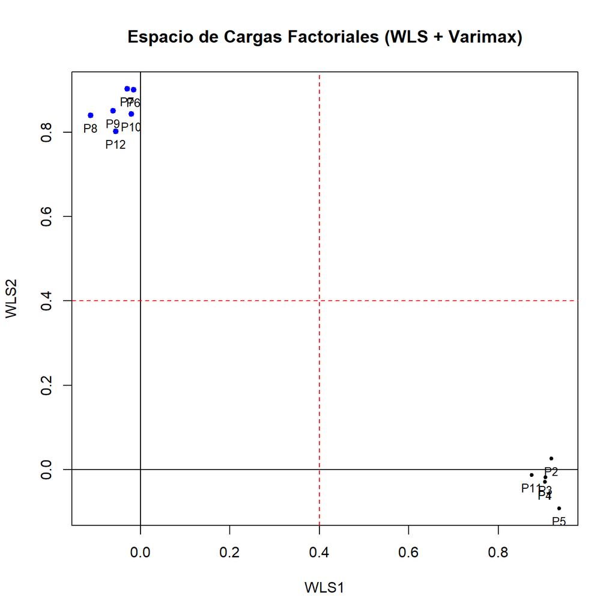

```r
# Gráfico de Cargas Factoriales (Estilo estándar de clase)
fa.plot(factorial_final,
        labels = rownames(factorial_final$loadings),
        main = "Espacio de Cargas Factoriales (WLS + Varimax)",
        cex = 0.8,
        pch = 19)

# Líneas de referencia para identificar cargas significativas (> 0.40)
abline(h = c(-0.4, 0.4), v = c(-0.4, 0.4), lty = 2, col = "red")
```

**Interpretación del Mapa de Cargas:**

El gráfico confirma una **Estructura Simple** clara, objetivo ideal de cualquier Análisis Factorial. Todos los ítems se ubican bien por fuera de las líneas de referencia (> 0.40), confirmando que la totalidad de las cargas son estadísticamente significativas.

- **Eje Horizontal (Factor 1 — Seguridad):** Los ítems P1, P2, P3, P4, P5 y P11 se sitúan en el extremo derecho del gráfico, muy próximos al eje horizontal y lejos del origen. El ítem **P5** es el más alejado, consistente con su carga máxima de 0.936. Esto confirma que son indicadores puros de la cultura de prevención de riesgos, sin interferencias del Factor 2.
- **Eje Vertical (Factor 2 — Hábitos):** Los ítems P6, P7, P8, P9, P10 y P12 se concentran en la parte superior del gráfico. **P7** y **P6** son los más extremos, en línea con sus cargas de 0.904 y 0.902 respectivamente. Ninguno de estos ítems presenta proyección relevante sobre el eje horizontal, evidenciando una separación limpia entre dimensiones.

## 1.12 Conclusiones y Recomendaciones

# 2 Bibliografía

- Aldás, J., & Uriel, E. (2017). Análisis multivariante aplicado con R. 2da Edición. Madrid: Ediciones Paraninfo.
- Revelle, W. (2024). psych: Procedures for Psychological, Psychometric, and Personality Research. R package.